# semana 2

Luis Ambrocio

# Leyendo MySQL

- Software de base de datos de código abierto gratuito y ampliamente utilizado
- Ampliamente utilizado en aplicaciones basadas en Internet.
- Los datos están estructurados en
  - Bases de datos
  - Tablas dentro de bases de datos
  - Campos dentro de tablas
- Cada fila se llama registro

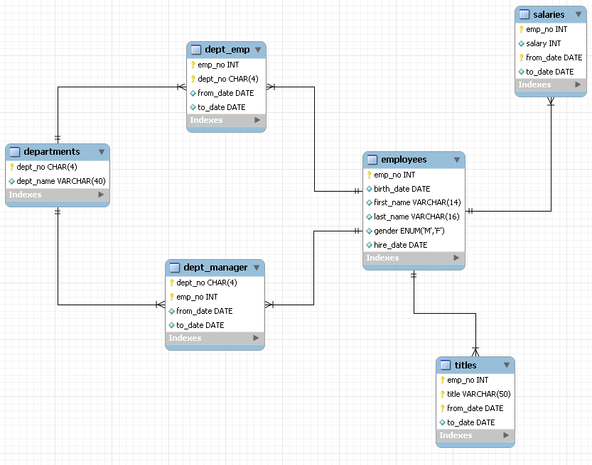

primero se installa MySQL

http://dev.mysql.com/doc/refman/5.7/en/installing.html

luego intsalar RMySQL

- Official instructions - http://biostat.mc.vanderbilt.edu/wiki/Main/RMySQL (may be useful for Mac/UNIX users as well)
- Potentially useful guide - http://www.ahschulz.de/2013/07/23/installing-rmysql-under-windows/

conectar y enumerar bases de datos

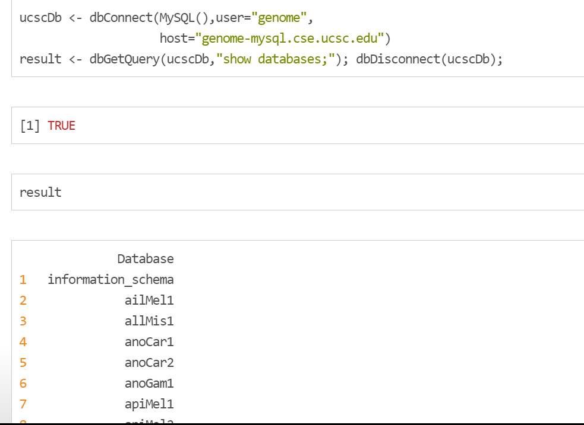

Conexión a hg19 y listas de tablas

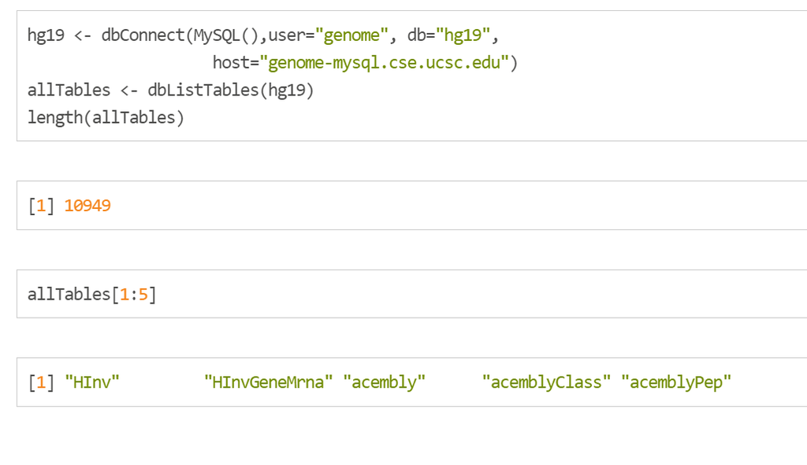

obteniendo dimenciones de una tabla especifica

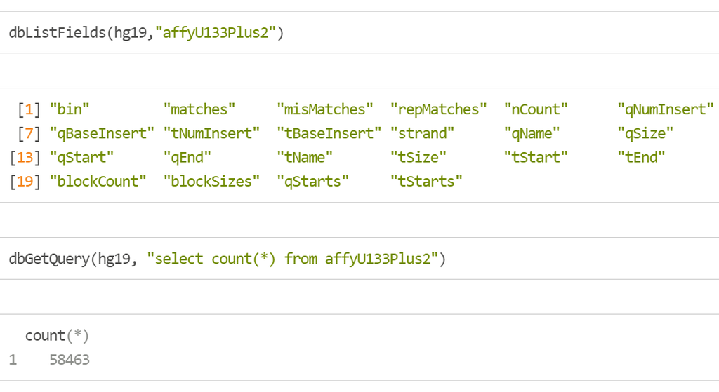

leyendo de la tabla

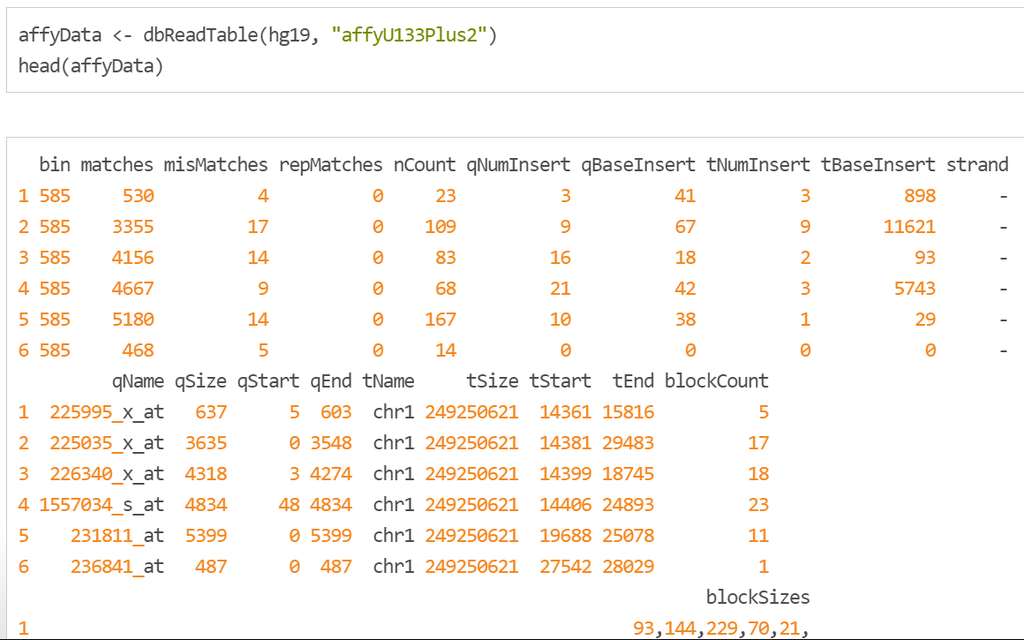

seleccionando un subconjunto especifico

[figure not shown]

cerrar la conexion

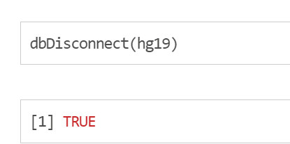

## Recursos adicionales

- Viñeta RMySQL http://cran.r-project.org/web/packages/RMySQL/RMySQL.pdf
- Lista de comandos http://www.pantz.org/software/mysql/mysqlcommands.html
  - **No, no elimine, agregue o combine elementos de ensembl. Solo seleccione .**
  - En general, tenga cuidado con los comandos mysql
- Una buena publicación de blog que resume algunos otros comandos http://www.r-bloggers.com/mysql-and-r/
- http://en.wikipedia.org/wiki/MySQL
- http://www.mysql.com/

# Leyendo HD5F

HDF5

- Se utiliza para almacenar grandes conjuntos de datos.
- Admite el almacenamiento de una variedad de tipos de datos
- Formato de datos jerárquico
- *grupos* que contienen cero o más conjuntos de datos y metadatos
  - Tener un *encabezado de grupo* con el nombre del grupo y una lista de atributos
  - Tener una *tabla de símbolos de grupo* con una lista de objetos en el grupo
- *datasets* matriz multidimensional de elementos de datos con metadatos
  - Tener un *encabezado* con nombre, tipo de datos, espacio de datos y diseño de almacenamiento
  - Tener un *data array* con los datos

http://www.hdfgroup.org/

```r
invisible(if(file.exists("example.h5")){file.remove("example.h5")})
```

```r
library(rhdf5)
file <- h5createFile("example.h5")
file
```

```
## [1] TRUE
```

- Esto instalará paquetes de Bioconductor http://bioconductor.org/, que se usa principalmente para genómica pero también tiene buenos paquetes de “big data”
- Se puede utilizar para interactuar con conjuntos de datos hdf5.
- Esta conferencia se basa muy de cerca en el tutorial de rhdf5 que se puede encontrar aquí [http://www.bioconductor.org/packages/release/bioc/vignettes/rhdf5/inst/doc/rhdf5.pdf](http://www.bioconductor.org/packages/release/bioc/%20viñetas%20/%20rhdf5%20/%20inst%20/%20doc%20/%20rhdf5.pdf)

crear grupos

```r
created = h5createGroup("example.h5","foo")
created = h5createGroup("example.h5","baa")
created = h5createGroup("example.h5","foo/foobaa")
h5ls("example.h5")
```

```
##   group   name     otype dclass dim
## 0     /    baa H5I_GROUP
## 1     /    foo H5I_GROUP
## 2  /foo foobaa H5I_GROUP
```

Escribir a grupos

```r
A = matrix(1:10,nr=5,nc=2)
h5write(A, "example.h5","foo/A")
B = array(seq(0.1,2.0,by=0.1),dim=c(5,2,2))
attr(B, "scale") <- "liter"
h5write(B, "example.h5","foo/foobaa/B")
h5ls("example.h5")
```

```
##         group   name       otype  dclass       dim
## 0           /    baa   H5I_GROUP
## 1           /    foo   H5I_GROUP
## 2        /foo      A H5I_DATASET INTEGER     5 x 2
## 3        /foo foobaa   H5I_GROUP
## 4 /foo/foobaa      B H5I_DATASET   FLOAT 5 x 2 x 2
```

escribir un conjunto de datos

```r
df = data.frame(1L:5L,seq(0,1,length.out=5),
  c("ab","cde","fghi","a","s"), stringsAsFactors=FALSE)
h5write(df, "example.h5","df")
h5ls("example.h5")
```

```
##         group   name       otype   dclass       dim
## 0           /    baa   H5I_GROUP
## 1           /     df H5I_DATASET COMPOUND         5
## 2           /    foo   H5I_GROUP
## 3        /foo      A H5I_DATASET  INTEGER     5 x 2
## 4        /foo foobaa   H5I_GROUP
## 5 /foo/foobaa      B H5I_DATASET    FLOAT 5 x 2 x 2
```

leyendo datos

```r
readA = h5read("example.h5","foo/A")
readB = h5read("example.h5","foo/foobaa/B")
readdf= h5read("example.h5","df")
readA
```

```
##      [,1] [,2]
## [1,]    1    6
## [2,]    2    7
## [3,]    3    8
## [4,]    4    9
## [5,]    5   10
```

Fragmentos de escritura y lectura

```r
h5write(c(12,13,14),"example.h5","foo/A",index=list(1:3,1))
h5read("example.h5","foo/A")
```

```
##      [,1] [,2]
## [1,]   12    6
## [2,]   13    7
## [3,]   14    8
## [4,]    4    9
## [5,]    5   10
```

## Notas y otros recursos

- hdf5 se puede utilizar para optimizar la lectura / escritura desde el disco en R
- El tutorial de rhdf5:
  - [http://www.bioconductor.org/packages/release/bioc/vignettes/rhdf5/inst/doc/rhdf5.pdf](http://www.bioconductor.org/packages/release/bioc/vignettes/rhdf5%20/inst/doc/rhdf5.pdf)
- El grupo HDF tiene información sobre HDF5 en general http://www.hdfgroup.org/HDF5/

# Leyendo datos de la web

Webscraping

**Webscraping**: Extracción de datos de forma programada del código HTML de sitios web.

- Puede ser una excelente manera de obtener datos [Cómo Netflix hizo ingeniería inversa a Hollywood] (http://www.theatlantic.com/technology/archive/2014/01/how-netflix-reverse-engineered-hollywood/282679/)
- Muchos sitios web tienen información que puede querer leer programáticamente
- En algunos casos, esto va en contra de los términos de servicio del sitio web.
- Intentar leer demasiadas páginas demasiado rápido puede bloquear su dirección IP

ejemplo

[figure not shown]

http://scholar.google.com/citations?user=HI-I6C0AAAAJ&hl=en

```r
con = url("http://scholar.google.com/citations?user=HI-I6C0AAAAJ&hl=en")
htmlCode = readLines(con)
close(con)
```

obteniendo informacion con paquete httr

```r
library(httr)
library(XML)
url <- "http://scholar.google.com/citations?user=HI-I6C0AAAAJ&hl=en"
html2 = GET(url)
content2 = content(html2,as="text")
parsedHtml = htmlParse(content2,asText=TRUE)
xpathSApply(parsedHtml, "//title", xmlValue)
```

```
## [1] "Jeff Leek - Google Scholar"
```

accesando a sitios web con contraseña

```r
pg1 = GET("http://httpbin.org/basic-auth/user/passwd")
pg1
```

```
## Response [http://httpbin.org/basic-auth/user/passwd]
##   Date: 2021-08-06 03:06
##   Status: 401
##   Content-Type: <unknown>
## <EMPTY BODY>
```

```r
pg2 = GET("http://httpbin.org/basic-auth/user/passwd",
    authenticate("user","passwd"))
pg2
```

```
## Response [http://httpbin.org/basic-auth/user/passwd]
##   Date: 2021-08-06 03:06
##   Status: 200
##   Content-Type: application/json
##   Size: 47 B
## {
##   "authenticated": true,
##   "user": "user"
## }
```

```r
names(pg2)
```

```
##  [1] "url"         "status_code" "headers"     "all_headers" "cookies"
##  [6] "content"     "date"        "times"       "request"     "handle"
```

usando handle

```r
google = handle("http://google.com")
pg1 = GET(handle=google,path="/")
pg2 = GET(handle=google,path="search")

pg1
```

[output not shown]

```r
pg2
```

[output not shown]

## Notas y otros recursos

- R Bloggers tiene varios ejemplos de raspado web http://www.r-bloggers.com/?s=Web+Scraping
- El archivo de ayuda httr tiene ejemplos útiles [http://cran.r-project.org/web/packages/httr/httr.pdf](http://cran.r-project.org/web/packages/httr/%20httr.pdf)
- Ver conferencias posteriores sobre API
- http://cran.r-project.org/web/packages/httr/httr.pdf
- http://en.wikipedia.org/wiki/Web_scraping

# Leyendo de APIs

Application programming interfaces(Interfaces de programación de aplicaciones)

[figure not shown]

crear una cuenta para ingresar a la API

https://dev.twitter.com/apps

luego crear una “app” y buscar los pasos para acceder a la api, el ejemplo siguiente es de una cuenta ya creada para fines academicos

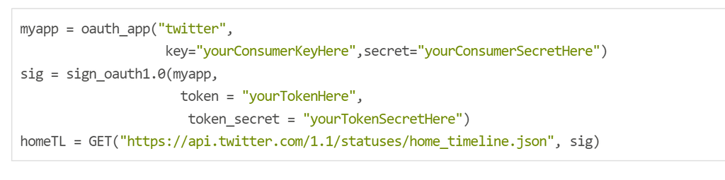

[figure not shown]

En general, mira la documentación.

- httr permite solicitudes `GET`,`POST`, `PUT`,`DELETE` si está autorizado
- Puede autenticarse con un nombre de usuario o una contraseña
- La mayoría de las API modernas usan algo como oauth
- httr funciona bien con Facebook, Google, Twitter, Githb, etc.

# Reading from other sources

Hay un paquete para eso

- Roger tiene un buen video sobre cómo hay paquetes R para la mayoría de las cosas a las que querrá acceder.
- Aquí voy a revisar brevemente algunos paquetes útiles
- En general, la mejor forma de averiguar si el paquete R existe es el “paquete R del mecanismo de almacenamiento de datos” de Google
  - Por ejemplo: “Paquete MySQL R”

*Interactuar más directamente con archivos*

- file: abre una conexión a un archivo de texto
- url: abre una conexión a una URL
- gzfile: abre una conexión a un archivo .gz
- bzfile: abre una conexión a un archivo .bz2
- *?connections* para más información
- Recuerde cerrar conexiones

## paquete foreing

- Carga datos de Minitab, S, SAS, SPSS, Stata, Systat
- Funciones básicas *read.foo*
  - read.arff (Weka)
  - read.dta (Stata)
  - read.mtp (Minitab)
  - read.octave (octava)
  - read.spss (SPSS)
  - read.xport (SAS)
- Consulte la página de ayuda para obtener más detalles.

http://cran.r-project.org/web/packages/foreign/foreign.pdf

## Ejemplos de otros paquetes de bases de datos

- RPostresSQL proporciona una conexión de base de datos compatible con DBI desde R. Tutorial- https://code.google.com/p/rpostgresql/, archivo de ayuda- http://cran.r-project.org/web/packages/RPostgreSQL/RPostgreSQL.pdf
- RODBC proporciona interfaces para múltiples bases de datos, incluidas PostgreQL, MySQL, Microsoft Access y SQLite. Tutorial - [http://cran.r-project.org/web/packages/RODBC/vignettes/RODBC.pdf](http://cran.r-project.org/web/packages/RODBC/vignettes/RODBC.%20pdf), archivo de ayuda - [http://cran.r-project.org/web/packages/RODBC/RODBC.pdf](http://cran.r-project.org/web/packages/RODBC/RODBC.%20pdf)
- RMongo http://cran.r-project.org/web/packages/RMongo/RMongo.pdf (ejemplo de Rmongo http://www.r-bloggers.com/r-and-mongodb/) y rmongodb proporcionan interfaces a MongoDb.

## Leer imágenes

- jpeg - http://cran.r-project.org/web/packages/jpeg/index.html
- readbitmap - http://cran.r-project.org/web/packages/readbitmap/index.html
- png - http://cran.r-project.org/web/packages/png/index.html
- EBImage (Bioconductor) - [http://www.bioconductor.org/packages/2.13/bioc/html/EBImage.html](http://www.bioconductor.org/packages/2.13/bioc/html/EBImage.%20html)

## Lectura de datos GIS

- rgdal - http://cran.r-project.org/web/packages/rgdal/index.html
- rgeos - http://cran.r-project.org/web/packages/rgeos/index.html
- raster - http://cran.r-project.org/web/packages/raster/index.html

## Leer datos musicales

- tuneR - http://cran.r-project.org/web/packages/tuneR/
- seewave - http://rug.mnhn.fr/seewave/